# 0909 Project Instagram Association

## Project

### Project 개요

- 홈트 관심도 분석 (코로나 이전 12개월(2019년) vs 이후 12개월(2020년))
- 뉴스 기사, 유튜브 채널 및 댓글, 인스타 계정 및 댓글을 수집하여 분석한다.
- 이 노트북은 인스타 데이터셋에 초점을 맞춘다.

## Instagram Crawling

### Strategies

- 검색 결과 페이지에서 게시물을 클릭하여, 사진 우측에 표시되는 본문 내용, 작성 일시 등을 수집한다.
- 게시글 정보를 수집한 후에는 다음 게시물로 넘어가서 수집한다.
  > - 게시글 화면 상의 오른쪽 화살표 > 를 클릭하여 다음 게시물로 넘어갈 것.
  > - 다음 게시물 클릭 > 게시물 정보 가져오는 과정을 원하는 횟수만큼 반복 처리할 것이다.

## Text Mining

### Data Preprocessing

- content, tags를 txt 파일로 만들기

```python
# === Import Modules ===
import numpy as np
import pandas as pd
import matplotlib.pyplot as plt
%matplotlib inline
%config InlineBackend.figure_format = 'retina'
```

- Load Data

```python
df1 = pd.read_csv("./data/instagram_crawling_ohaun.csv", encoding='utf-8-sig')
df2 = pd.read_csv("./data/instagram_crawling_hometraining.csv", encoding="utf-8-sig")
df3 = pd.read_csv("./data/instagram_crawling_homet.csv", encoding="utf-8-sig")
```

- Data Shape 확인하기

```python
print(df1.shape, df2.shape, df3.shape)
```

```
(2474, 5) (1999, 5) (1970, 5)
```

#### Merge Data

- 오하운, 홈트레이닝, 홈트 게시물을 하나의 데이터 프레임으로 생성

```python
df = df1.append(df2, ignore_index=True).append(df3, ignore_index=True)
df.shape
```

```
(6443, 5)
```

```python
df
```

|  | content | tags | date | like | place |
| --- | --- | --- | --- | --- | --- |
| 0 | 운동으로도 안풀리는게 있다....#오하운 #루틴 #루틴만들기 #라이딩 #싸이클 #사... | ['#오하운', '#루틴', '#루틴만들기', '#라이딩', '#싸이클', '#사이... | 2021-09-05 | 311 | NaN |
| 1 | 날씨 맑음☀️어제에 이어 오늘도 맑아요🌤 그림같은 구름에 예쁜 하늘😍 기분이도 좋네... | ['#브롬톤', '#남산', '#한강라이딩', '#자전거', '#자전거타는여자', ... | 2021-09-05 | 556 | NaN |
| 2 | 하체핫체🔥오늘 필테시간에 리포머에서 버피를했다지옥과 천국을 오가는 느낌😇쌤 덕분에 ... | ['#일상소통', '#운동소통', '#다이어트소통'] | 2021-09-06 | 309 | NaN |
| 3 | 오하운가슴운동 40분야외러닝 5k 33분다시는 하체운동을 우습게 보지 말라!!불금에... | [] | 2021-09-05 | 217 | NaN |
| 4 | 등 뇸!🍠워밍업20r 본세트 15r5s루마니안데드 60케이블풀다운 30시티드케이블로... | ['#일상', '#운동소통', '#다이어트소통'] | 2021-08-31 | 724 | NaN |
| ... | ... | ... | ... | ... | ... |
| 6438 | #주말일상 .오랜만에 피티받고 마무리 유산소까지😆바프찍구 개인운동 못 했었는데유지어... | ['#주말일상', '#주말운동', '#유산소', '#런닝머신', '#자기관리'] | 2021-09-05 | 51 | NaN |
| 6439 | 나의 꿀밤을 받아르아~~ | [] | 2021-09-05 | 95 | NaN |
| 6440 | 어제 벌초 간다고 새벽부터 움직이고 하루종일 운전 하고 나니까 일요일 사라졌네? | [] | 2021-09-05 | 159 | NaN |
| 6441 | 하나성공💪🏻 그새 살쪗네; | [] | 2021-09-05 | 0 | NaN |
| 6442 | Brand Mall 🤍#디올*(문의는 프로필 하단 링크로 도와드림니다)🏷문의카톡 B... | ['#디올*(문의는', '#오오티디룩', '#루이비통가방', '#샤넬가방', '#펜... | 2021-09-05 | 334 | NaN |

6443 rows × 5 columns

- content의 # 제거

```python
df["content"] = df["content"].str.replace(pat=r'\n', repl= r' ', regex=True)
df["content"] = df["content"].str.replace(pat=r'[^\w]', repl= r' ', regex=True)  # replace all special symbols to space
df["content"] = df["content"].str.replace(pat=r'[\s\s+]', repl= r' ', regex=True)  # replace multiple spaces with a single space
df["tags"] = df["tags"].str.replace(pat=r"[',']", repl= r' ', regex=True)  # replace all special symbols to space
df.head()
```

|  | content | tags | date | like | place |
| --- | --- | --- | --- | --- | --- |
| 0 | 운동으로도 안풀리는게 있다 오하운 루틴 루틴만들기 라이딩 싸이클 사... | [ #오하운 #루틴 #루틴만들기 #라이딩 #싸이클 #사이... | 2021-09-05 | 311 | NaN |
| 1 | 날씨 맑음 어제에 이어 오늘도 맑아요 그림같은 구름에 예쁜 하늘 기분이도 좋네... | [ #브롬톤 #남산 #한강라이딩 #자전거 #자전거타는여자 ... | 2021-09-05 | 556 | NaN |
| 2 | 하체핫체 오늘 필테시간에 리포머에서 버피를했다지옥과 천국을 오가는 느낌 쌤 덕분에 ... | [ #일상소통 #운동소통 #다이어트소통 ] | 2021-09-06 | 309 | NaN |
| 3 | 오하운가슴운동 40분야외러닝 5k 33분다시는 하체운동을 우습게 보지 말라 불금에... | [] | 2021-09-05 | 217 | NaN |
| 4 | 등 뇸 워밍업20r 본세트 15r5s루마니안데드 60케이블풀다운 30시티드케이블로... | [ #일상 #운동소통 #다이어트소통 ] | 2021-08-31 | 724 | NaN |

- 통합 데이터셋을 instagram_crawling.csv 으로 저장

```python
df.to_csv("./data/instagram_crawling.csv", encoding='utf-8-sig', index=False)
```

### 빈도수 분석

```python
df = pd.read_csv("./data/instagram_crawling.csv", encoding='utf-8-sig')
df.head()
```

|  | content | tags | date | like | place |
| --- | --- | --- | --- | --- | --- |
| 0 | 운동으로도 안풀리는게 있다 오하운 루틴 루틴만들기 라이딩 싸이클 사... | [ #오하운 #루틴 #루틴만들기 #라이딩 #싸이클 #사이... | 2021-09-05 | 311 | NaN |
| 1 | 날씨 맑음 어제에 이어 오늘도 맑아요 그림같은 구름에 예쁜 하늘 기분이도 좋네... | [ #브롬톤 #남산 #한강라이딩 #자전거 #자전거타는여자 ... | 2021-09-05 | 556 | NaN |
| 2 | 하체핫체 오늘 필테시간에 리포머에서 버피를했다지옥과 천국을 오가는 느낌 쌤 덕분에 ... | [ #일상소통 #운동소통 #다이어트소통 ] | 2021-09-06 | 309 | NaN |
| 3 | 오하운가슴운동 40분야외러닝 5k 33분다시는 하체운동을 우습게 보지 말라 불금에... | [] | 2021-09-05 | 217 | NaN |
| 4 | 등 뇸 워밍업20r 본세트 15r5s루마니안데드 60케이블풀다운 30시티드케이블로... | [ #일상 #운동소통 #다이어트소통 ] | 2021-08-31 | 724 | NaN |

#### 분석할 content와 tag만 있는 tsv 파일 생성

```python
df['content'].to_csv("./data/content.tsv", sep="\t", index=False, encoding='utf-8-sig')
df['tags'].to_csv("./data/tags.tsv", sep="\t", index=False, encoding='utf-8-sig')
```

- KoNLPy 패키지

```python
! pip install konlpy
```

#### KoNLPy 분석

```python
# === Import Modules ===
from konlpy.tag import Okt
from collections import Counter

okt = Okt()
```

```python
with open('./data/content.tsv', 'r', encoding='utf-8-sig') as f:
    content = f.read()

with open('./data/tags.tsv', 'r', encoding='utf-8-sig') as f:
    tags = f.read()
```

#### 형태소 분석

- 길이가 1보다 큰 단어 추출

```python
content_morphs = okt.morphs(content)
tags_morphs = okt.morphs(tags)
```

```python
# 불용어
stop_words = ['..', r'\n', '\n', '합니다', '있는', '없는', '에는', '처럼', '[]', ',', '[', ']', "',", \
              '*(', ')', "['#", '#', '❤️', '으로', ".',", '♀️', '..', '하는', '하고', '에서', '200', \
              '...', '너무', '!!', '좋은', '까지','✔️', '문의', '입니다','스타','그램', ' ', "]"]

# 길이 1 이상인 단어 담을 리스트
content_words = []
tags_words = []

# 추출
for morph in content_morphs:
    if len(morph)>1:
        if morph not in stop_words:
            content_words.append(morph)

for morph in tags_morphs:
    if len(morph)>1:
        if morph not in stop_words:
            tags_words.append(morph)
```

#### 빈도 수가 가장 높은 순 추출하기

- 200개 추출

```python
content_count = Counter(content_words)
content_morph_list = content_count.most_common(200)

tags_count = Counter(tags_words)
tags_morph_list = tags_count.most_common(200)
```

- 상위 빈도수 200위 키워드 추출하여 각각 파일로 저장

```python
with open('./data/content_morph.txt', 'w', encoding='utf-8-sig') as f:
    f.writelines(str(content_morph_list))

with open('./data/tags_morph.txt', 'w', encoding='utf-8-sig') as f:
    f.writelines(str(tags_morph_list))

print(len(content_morph_list), len(tags_morph_list))
```

```
200 200
```

```python
columns = ['morph', '횟수']
content_morph = pd.DataFrame(content_morph_list, columns=columns)
tags_morph = pd.DataFrame(tags_morph_list, columns=columns)
```

- Content 키워드 빈도수

```python
content_morph.head(60)
```

|  | morph | 횟수 |
| --- | --- | --- |
| 0 | 운동 | 11642 |
| 1 | 홈트 | 2735 |
| 2 | 오늘 | 2613 |
| 3 | 다이어트 | 2444 |
| 4 | 트레이닝 | 1715 |
| 5 | 하운 | 1705 |
| 6 | \n | 1587 |
| 7 | kg | 1382 |
| 8 | 식단 | 1363 |
| 9 | 바디 | 1349 |
| 10 | 여자 | 1261 |
| 11 | 필라테스 | 1222 |
| 12 | 기록 | 1143 |
| 13 | 아침 | 1100 |
| 14 | 요가 | 1083 |
| 15 | 러닝 | 1021 |
| 16 | 일상 | 957 |
| 17 | 하루 | 928 |
| 18 | 걷기 | 842 |
| 19 | 20 | 795 |
| 20 | 남자 | 770 |
| 21 | 린지 | 769 |
| 22 | 시작 | 767 |
| 23 | 10 | 759 |
| 24 | 헬스 | 732 |
| 25 | 프로필 | 729 |
| 26 | 저녁 | 703 |
| 27 | 시간 | 696 |
| 28 | 소통 | 690 |
| 29 | 관리 | 661 |
| 30 | 스트레칭 | 644 |
| 31 | 함께 | 629 |
| 32 | set | 629 |
| 33 | 헬린 | 623 |
| 34 | 건강 | 578 |
| 35 | 9월 | 575 |
| 36 | 세트 | 574 |
| 37 | 습관 | 572 |
| 38 | 모닝 | 572 |
| 39 | 유지 | 564 |
| 40 | 달리기 | 557 |
| 41 | 많이 | 551 |
| 42 | 복근 | 549 |
| 43 | 가슴 | 542 |
| 44 | 산소 | 540 |
| 45 | 사진 | 538 |
| 46 | 주말 | 533 |
| 47 | 하기 | 517 |
| 48 | 제품 | 515 |
| 49 | 생각 | 513 |
| 50 | 100 | 495 |
| 51 | 맞팔 | 492 |
| 52 | 근육 | 491 |
| 53 | 좋아요 | 480 |
| 54 | 스쿼트 | 477 |
| 55 | 보다 | 467 |
| 56 | 일기 | 465 |
| 57 | 15 | 460 |
| 58 | 부터 | 459 |
| 59 | 루틴 | 447 |

- Tags 키워드 빈도수

```python
tags_morph.head(60)
```

|  | morph | 횟수 |
| --- | --- | --- |
| 0 | #홈트 | 1782 |
| 1 | #오하운 | 1561 |
| 2 | #홈트레이닝 | 1338 |
| 3 | #운동 | 1006 |
| 4 | #다이어트 | 974 |
| 5 | #운동하는여자 | 821 |
| 6 | #운동스타그램 | 592 |
| 7 | #일상 | 523 |
| 8 | #헬린이 | 472 |
| 9 | #운동하는남자 | 461 |
| 10 | #헬스 | 445 |
| 11 | #운동기록 | 388 |
| 12 | #헬스타그램 | 328 |
| 13 | #필라테스 | 296 |
| 14 | #다이어터 | 275 |
| 15 | #유지어터 | 253 |
| 16 | #눈바디 | 227 |
| 17 | #러닝 | 226 |
| 18 | #운동하는직장인 | 223 |
| 19 | #식단 | 217 |
| 20 | #요가 | 206 |
| 21 | #소통 | 201 |
| 22 | #맞팔 | 192 |
| 23 | #workout | 190 |
| 24 | #좋아요 | 186 |
| 25 | #미라클모닝 | 184 |
| 26 | #바디프로필 | 177 |
| 27 | #diet | 177 |
| 28 | #daily | 174 |
| 29 | #운동소통 | 172 |
| 30 | #달리기 | 169 |
| 31 | #웨이트 | 158 |
| 32 | #건강 | 156 |
| 33 | #다이어트식단 | 153 |
| 34 | #데일리 | 150 |
| 35 | #맨몸운동 | 150 |
| 36 | #런스타그램 | 148 |
| 37 | #셀카 | 147 |
| 38 | #좋반 | 142 |
| 39 | #런린이 | 139 |
| 40 | #걷기 | 138 |
| 41 | #바디체크 | 133 |
| 42 | #스트레칭 | 131 |
| 43 | #운동하는엄마 | 130 |
| 44 | #등산 | 130 |
| 45 | #만보걷기 | 118 |
| 46 | #셀피 | 117 |
| 47 | #좋아요반사 | 116 |
| 48 | #아침운동 | 116 |
| 49 | #유산소운동 | 113 |
| 50 | #식단기록 | 107 |
| 51 | #ootd | 105 |
| 52 | #running | 105 |
| 53 | #선팔 | 105 |
| 54 | #운동일기 | 102 |
| 55 | #fitness | 101 |
| 56 | #자기관리 | 101 |
| 57 | #홈트하는여자 | 99 |
| 58 | #근력운동 | 96 |
| 59 | #조깅 | 94 |

## WordCloud

```python
with open('./data/content_morph.txt', 'r', encoding='utf-8-sig') as f:
    content = f.read()

with open('./data/tags_morph.txt', 'r', encoding='utf-8-sig') as f:
    tags = f.read()
```

```python
! pip install wordcloud
```

```python
import numpy as np
from PIL import Image
from wordcloud import WordCloud
from wordcloud import STOPWORDS
import matplotlib.pyplot as plt

mask = np.array(Image.open('./data/image.jpg'))
```

```python
# 색 지정(인터넷 검색 더 해봐야 할듯),,
from matplotlib.colors import LinearSegmentedColormap
colors = ["#c6a554", "#5b1a20", "#ceaea3", "#1f3238", "#48372d"]
#https://www.color-hex.com/color-palettes/ (색 찾아서 사용)
cmap = LinearSegmentedColormap.from_list('mycmap', colors)
```

```python
word_cloud = WordCloud (font_path = 'c:/Windows/Fonts/H2GTRM.TTF', background_color = 'white', stopwords=stop_w, \
                max_words=1000, mask=mask, max_font_size = 500, random_state = None, colormap=cmap)

content_wc = word_cloud.generate(content)
```

```python
from IPython.display import set_matplotlib_formats
%matplotlib inline
%config InlineBackend.figure_format= 'retina'
```

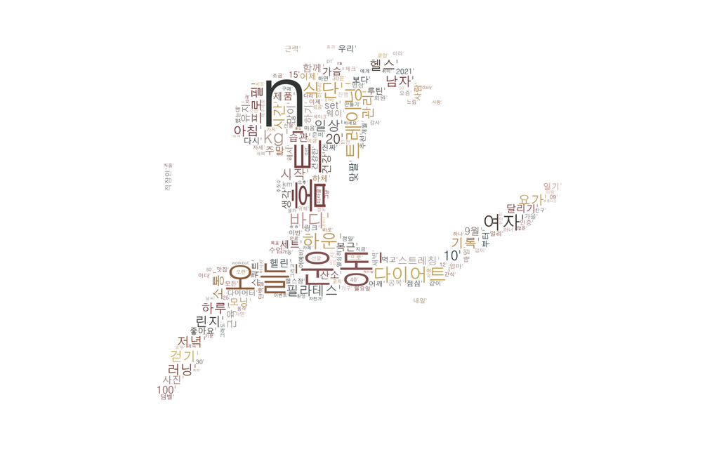

```python
plt.figure(figsize=(15,10))
plt.axis("off")
plt.imshow(content_wc)
plt.show()
plt.savefig('./data/content_wc.png')
```

```python
mask = np.array(Image.open('./data/mask_image.png'))
```

```python
word_cloud2 = WordCloud (font_path = 'c:/Windows/Fonts/H2GTRM.TTF', background_color = 'white', stopwords=stop_w, \
                max_words=1000, mask=mask, max_font_size = 500, random_state = None, colormap=cmap)
tags_wc = word_cloud2.generate(tags)
```

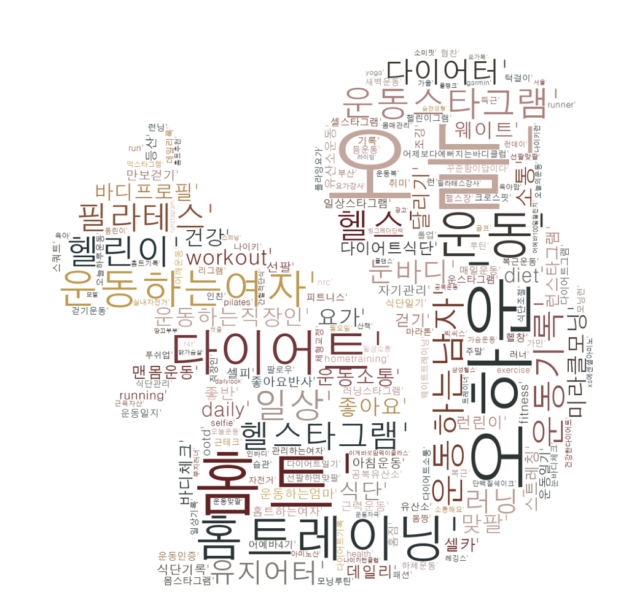

```python
plt.figure(figsize=(15,10))
plt.axis("off")
plt.imshow(tags_wc)
plt.show()
plt.savefig('./data/tags_wc.png')
```

## 빈도수 상위 명사 시각화

```python
with open('./data/content.tsv', 'r', encoding='utf-8-sig') as f:
    content = f.read()
```

```python
#형태소 단위로 분해
from konlpy.tag import Okt, Kkma
from collections import Counter
okt = Okt()
morphs = okt.nouns(content)


#길이가 1인것들 제거
words = []
for n in morphs:
    if len(n)>1:
        words.append(n)
count = Counter(words)
morphs_list = count.most_common(300)

print(morphs_list)
```

```
[('운동', 11617), ('그램', 2889), ('홈트', 2735), ('오늘', 2611), ('다이어트', 2442), ('스타', 2389), ('트레이닝', 1715), ('하운', 1705), ('식단', 1363), ('바디', 1349), ('여자', 1261), ('필라테스', 1221), ('기록', 1142), ('아침', 1099), ('요가', 1082), ('러닝', 1021), ('일상', 957), ('하루', 928), ('걷기', 833), ('남자', 770), ('린지', 769), ('시…
```

```python
from nltk import Text

text = Text(words, name = "Instagram")
text.count('홈트')
print(text)
```

```
<Text: Instagram>
```

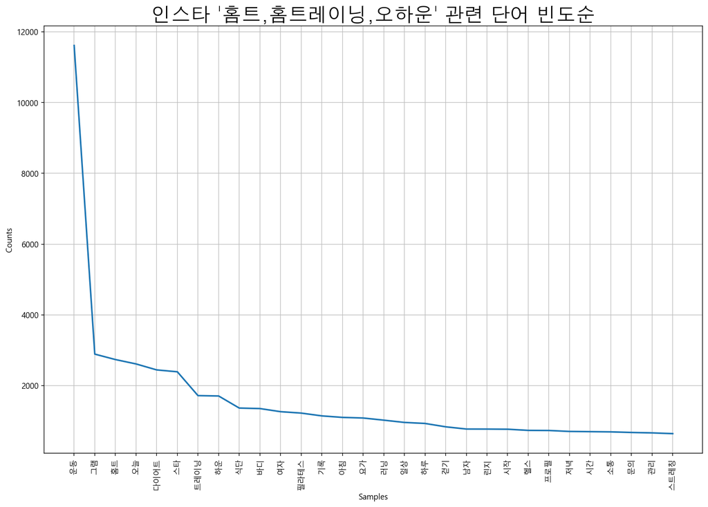

```python
import matplotlib.font_manager as fm
from matplotlib import font_manager, rc
%matplotlib inline
%config InlineBackend.figure_format = 'retina'

font_path = 'c:/Windows/Fonts/H2GTRM.TTF'
fontprop = fm.FontProperties(fname=font_path, size=25)
rc('font', family='Malgun Gothic')


plt.figure(figsize = (15,10))
plt.title("인스타 '홈트,홈트레이닝,오하운' 관련 단어 빈도순",fontproperties=fontprop)
#상위20개 명사 (빈도순 정렬)
text.plot(30)
#plt.show()
plt.show()
```

## 해시태그 Association Analysis

- 어떤 태그끼리 상호 연관성이 있을까?
- 연관분석은 데이터 사이에 **자주 발생하는 속성을 찾고**, 그 속성 사이에 **어느 정도 연관성이 있는지** 분석하는 방법이다.
  > - apriori, FP-growth, DHP 등의 연관분석 알고리즘
  > - apriori 알고리즘은 구현이 간단하고 성능이 높다.
  > - apyori 패키지
- 연관 규칙 ( X → Y)가 있다면,
  > - X는 전제(Antecedent, LHS(Left Hand Side))를 의미하고,
  > - Y는 결과(Consequent, RHS(Right Hand SIde))를 의미한다.

### Evaluation

- 연관 규칙이 유효하다는 것은, 연관 규칙이 최소 지지도(Support) 이상이고, 최소 신뢰도(Confidence) 이상이라는 뜻이다.
- **지지도 (Support)**
  > - 전체 Transaction에서 Element(X, Y)를 포함하는 Transaction의 비율
  > - 연관 규칙이 얼마나 중요한지 평가
  > - 얼마나 자주 발생했는가, 높은 효용성
  > - 필요 조건
- **신뢰도 (Confidence)**
  > - X를 포함하는 Transaction 중 Y도 포함하는 Transaction의 비율
  > - 연관 규칙이 얼마나 믿을만한지 평가
  > - 특정 Transaction에서 포함된 Element의 발생 빈도
  > - Support가 같은 특정 연관 규칙 중에서 더 높은 신뢰도를 가지면, 더 정확하다고 할 수 있다.
  > - 충분 조건
- Support와 Confidence는 확률값으로, 1에 가까울수록 연관 관계가 크고 0에 가까울수록 연관관계가 작다.
- 연관규칙이 아무리 높은 Support와 Confidence를 갖더라도, 향상도(Lift)가 1에 가까우면, 두 Element 간의 상관관계는 적다.
  > - Lift가 1이면 독립관계로, 두 Elements가 서로 독립이며 연관성을 갖지 않는다.
  > - Lift가 1보다 크면 양의 상관관계로 연관성이 높다.
  > - Lift가 0보다 크고 1보다 작으면, 음의 상관관계이며, X를 구매하면 Y를 구매하지 않는다.

## Transaction Data

- Transaction은 서로 관계가 있는 데이터의 모음
  > - Association Analysis는 Transaction에서 Association Rule을 도출한다.
  > - Python에서 Transaction Data는 이중 List 형식이다.

### CSV 파일로 Transaction Data 생성

- CSV 파일에서 Transaction 데이터 생성하기
  > - 각 행을 List의 List 구조로 만들기
- Transaction Data (List of List)는 연관분석을 통해 '홈트를 태그하는 사람은 오하운도 태그할까?' 에 대한 질문의 답을 내릴 수 있다.

```python
import pandas as pd

df = pd.read_csv("./data/tags.tsv", encoding="utf-8-sig")
```

```python
df
```

|  | tags |
| --- | --- |
| 0 | [ #오하운 #루틴 #루틴만들기 #라이딩 #싸이클 #사이... |
| 1 | [ #브롬톤 #남산 #한강라이딩 #자전거 #자전거타는여자 ... |
| 2 | [ #일상소통 #운동소통 #다이어트소통 ] |
| 3 | [] |
| 4 | [ #일상 #운동소통 #다이어트소통 ] |
| ... | ... |
| 6438 | [ #주말일상 #주말운동 #유산소 #런닝머신 #자기관리 ] |
| 6439 | [] |
| 6440 | [] |
| 6441 | [] |
| 6442 | [ #디올*(문의는 #오오티디룩 #루이비통가방 #샤넬가방 #펜... |

6443 rows × 1 columns

- df의 row를 list로 변환하여 list of list로 만든다

```python
import re
p = re.compile(r'#\w+')

tags = [] # transaction data

# transaction 리스트에 단어가 형태소 분석 후 명사만 추출하여 단어길이가 1보다 큰 단어만 담기
for row in range(1, df.shape[0]):

    try:
        result = p.findall(df.loc[row])
    except:
        result = []
    tags.append(result)
```

```python
tags
```

[output not shown]

[output cut: 9528 more lines]

[output not shown]

```python
len(tags)
```

```
6442
```

### 연관분석

- List of List 형식으로 만든 transaction data로 연관분석 수행하기.
  > - Support가 너무 작으면, Association Analysis에 많은 시간이 소요된다.

```python
from apyori import apriori

rules = apriori(tags, min_support=0.01, min_cofidence=0.01)
results = list(rules)
results
```

[output not shown]

[output cut: 639 more lines]

- Association Analysis 결과를 DataFrame으로 만들기

```python
# Stop Words List
stop_words = {}
```

```python
import pandas as pd
from tqdm import tqdm

# Empty DataFrame
df = pd.DataFrame(None, columns=['LHS', 'RHS', 'SUPPORT', 'CONFIDENCE', 'LIFT'])

idx = 0
for result in tqdm(results):
    support = result[1]
    ordered_statistics = result[2]
    for ordered_item in ordered_statistics:
        lhs = " ".join(x.strip() for x in ordered_item[0])
        rhs = " ".join(x.strip() for x in ordered_item[1])
        confidence = ordered_item[2]
        lift = ordered_item[3]
        df.loc[idx] = [lhs, rhs, support, confidence, lift]
        idx += 1
```

### 연관분석 탐색

```python
df.loc[df.LHS==""].sort_values(by=["SUPPORT"], ascending=False).iloc[60:].head(60)
```

|  | LHS | RHS | SUPPORT | CONFIDENCE | LIFT |
| --- | --- | --- | --- | --- | --- |
| 495 |  | #오하운 #일상 | 0.031512 | 0.031512 | 1.0 |
| 1302 |  | #다이어트 #홈트 #운동하는여자 | 0.031357 | 0.031357 | 1.0 |
| 561 |  | #헬린이 #운동 | 0.030891 | 0.030891 | 1.0 |
| 693 |  | #헬린이 #운동하는여자 | 0.030736 | 0.030736 | 1.0 |
| 804 |  | #헬린이 #헬스타그램 | 0.030270 | 0.030270 | 1.0 |
| 282 |  | #헬린이 #다이어트 | 0.030115 | 0.030115 | 1.0 |
| 801 |  | #헬린이 #헬스 | 0.029960 | 0.029960 | 1.0 |
| 795 |  | #필라테스 #홈트 | 0.029960 | 0.029960 | 1.0 |
| 672 |  | #운동하는남자 #홈트레이닝 | 0.029960 | 0.029960 | 1.0 |
| 47 |  | #소통 | 0.029649 | 0.029649 | 1.0 |
| 7 |  | #workout | 0.029494 | 0.029494 | 1.0 |
| 642 |  | #헬스타그램 #운동스타그램 | 0.029339 | 0.029339 | 1.0 |
| 636 |  | #헬린이 #운동스타그램 | 0.029183 | 0.029183 | 1.0 |
| 32 |  | #맞팔 | 0.028873 | 0.028873 | 1.0 |
| 813 |  | #헬스 #헬스타그램 | 0.028873 | 0.028873 | 1.0 |
| 534 |  | #운동하는남자 #운동 | 0.028718 | 0.028718 | 1.0 |
| 37 |  | #미라클모닝 | 0.028563 | 0.028563 | 1.0 |
| 219 |  | #다이어터 #홈트 | 0.027942 | 0.027942 | 1.0 |
| 80 |  | #좋아요 | 0.027786 | 0.027786 | 1.0 |
| 771 |  | #일상 #홈트레이닝 | 0.027631 | 0.027631 | 1.0 |
| 1 |  | #diet | 0.027476 | 0.027476 | 1.0 |
| 39 |  | #바디프로필 | 0.027476 | 0.027476 | 1.0 |
| 1701 |  | #홈트 #운동 #운동스타그램 | 0.027321 | 0.027321 | 1.0 |
| 567 |  | #운동 #헬스타그램 | 0.027165 | 0.027165 | 1.0 |
| 0 |  | #daily | 0.027010 | 0.027010 | 1.0 |
| 1792 |  | #홈트 #운동 #운동하는여자 | 0.026855 | 0.026855 | 1.0 |
| 2436 |  | #헬스 #홈트 #홈트레이닝 | 0.026700 | 0.026700 | 1.0 |
| 1904 |  | #헬스 #운동 #홈트레이닝 | 0.026700 | 0.026700 | 1.0 |
| 1827 |  | #홈트 #일상 #운동 | 0.026700 | 0.026700 | 1.0 |
| 61 |  | #운동소통 | 0.026389 | 0.026389 | 1.0 |
| 243 |  | #식단 #다이어트 | 0.026389 | 0.026389 | 1.0 |
| 2128 |  | #홈트 #홈트레이닝 #운동스타그램 | 0.026234 | 0.026234 | 1.0 |
| 1309 |  | #다이어트 #홈트레이닝 #운동하는여자 | 0.026079 | 0.026079 | 1.0 |
| 21 |  | #달리기 | 0.025768 | 0.025768 | 1.0 |
| 2156 |  | #운동하는남자 #홈트 #운동하는여자 | 0.025768 | 0.025768 | 1.0 |
| 639 |  | #헬스 #운동스타그램 | 0.025768 | 0.025768 | 1.0 |
| 684 |  | #일상 #운동하는여자 | 0.025303 | 0.025303 | 1.0 |
| 1120 |  | #다이어트 #헬스 #운동 | 0.025303 | 0.025303 | 1.0 |
| 522 |  | #홈트 #요가 | 0.024992 | 0.024992 | 1.0 |
| 618 |  | #운동하는남자 #운동스타그램 | 0.024992 | 0.024992 | 1.0 |
| 600 |  | #운동기록 #홈트레이닝 | 0.024527 | 0.024527 | 1.0 |
| 825 |  | #헬스타그램 #홈트레이닝 | 0.024371 | 0.024371 | 1.0 |
| 71 |  | #웨이트 | 0.024371 | 0.024371 | 1.0 |
| 195 |  | #다이어트 #다이어터 | 0.024216 | 0.024216 | 1.0 |
| 450 |  | #식단 #운동 | 0.024216 | 0.024216 | 1.0 |
| 330 |  | #오하운 #러닝 | 0.024216 | 0.024216 | 1.0 |
| 660 |  | #운동하는남자 #헬린이 | 0.024216 | 0.024216 | 1.0 |
| 8 |  | #건강 | 0.024061 | 0.024061 | 1.0 |
| 264 |  | #운동하는남자 #다이어트 | 0.024061 | 0.024061 | 1.0 |
| 699 |  | #헬스타그램 #운동하는여자 | 0.023906 | 0.023906 | 1.0 |
| 477 |  | #운동기록 #오하운 | 0.023906 | 0.023906 | 1.0 |
| 108 |  | #diet #다이어트 | 0.023595 | 0.023595 | 1.0 |
| 663 |  | #운동하는남자 #헬스 | 0.023440 | 0.023440 | 1.0 |
| 666 |  | #운동하는남자 #헬스타그램 | 0.023285 | 0.023285 | 1.0 |
| 34 |  | #맨몸운동 | 0.023285 | 0.023285 | 1.0 |
| 1393 |  | #다이어트 #홈트 #헬스 | 0.023129 | 0.023129 | 1.0 |
| 30 |  | #런스타그램 | 0.022974 | 0.022974 | 1.0 |
| 20 |  | #다이어트식단 | 0.022974 | 0.022974 | 1.0 |
| 501 |  | #헬린이 #오하운 | 0.022664 | 0.022664 | 1.0 |
| 2240 |  | #운동하는남자 #홈트 #홈트레이닝 | 0.022664 | 0.022664 | 1.0 |

- LHS 에 'X', RHS에 'Y'가 있는 연관규칙을 LIFT가 큰 순으로 출력하기.
  > - #홈트와 #홈트레이닝

```python
df.loc[(df.LHS.str.contains("#홈트")) & (df.RHS.str.contains("#홈트레이닝"))].sort_values(by=["LIFT"], ascending=False).head(60)
```

|  | LHS | RHS | SUPPORT | CONFIDENCE | LIFT |
| --- | --- | --- | --- | --- | --- |
| 3915 | #헬스타그램 #홈트 #운동 | #헬스 #홈트레이닝 | 0.010711 | 0.522727 | 14.640909 |
| 3907 | #헬스 #홈트 | #헬스타그램 #운동 #홈트레이닝 | 0.010711 | 0.225490 | 14.241253 |
| 3913 | #헬스 #홈트 #운동 | #헬스타그램 #홈트레이닝 | 0.010711 | 0.303965 | 12.472235 |
| 3909 | #홈트 #헬스타그램 | #헬스 #운동 #홈트레이닝 | 0.010711 | 0.330144 | 12.365027 |
| 3721 | #식단 #홈트 | #다이어트 #운동 #홈트레이닝 | 0.011487 | 0.506849 | 11.745048 |
| 3701 | #헬스 #홈트 | #헬스타그램 #홈트레이닝 | 0.012884 | 0.271242 | 11.129553 |
| 3703 | #홈트 #헬스타그램 | #헬스 #홈트레이닝 | 0.012884 | 0.397129 | 11.123071 |
| 3729 | #다이어트 #홈트 #운동 | #식단 #홈트레이닝 | 0.011487 | 0.234177 | 10.775497 |
| 3688 | #홈트 #헬스타그램 | #헬린이 #홈트레이닝 | 0.010245 | 0.315789 | 9.733568 |
| 3686 | #헬린이 #홈트 | #헬스타그램 #홈트레이닝 | 0.010245 | 0.233216 | 9.569265 |
| 3727 | #식단 #다이어트 #홈트 | #운동 #홈트레이닝 | 0.011487 | 0.601626 | 8.709382 |
| 2473 | #다이어트 #홈트 | #diet #홈트레이닝 | 0.011021 | 0.117550 | 8.605170 |
| 3732 | #식단 #홈트 #운동 | #다이어트 #홈트레이닝 | 0.011487 | 0.678899 | 8.475713 |
| 3822 | #다이어트 #홈트 #헬스 | #운동 #홈트레이닝 | 0.013195 | 0.570470 | 8.258352 |
| 2996 | #식단 #홈트 | #운동 #홈트레이닝 | 0.012574 | 0.554795 | 8.031430 |
| 3791 | #다이어트 #홈트 #일상 | #운동 #홈트레이닝 | 0.010245 | 0.545455 | 7.896221 |
| 3918 | #헬스 #홈트 #헬스타그램 | #운동 #홈트레이닝 | 0.010711 | 0.543307 | 7.865133 |
| 3673 | #헬스 #홈트 | #헬린이 #홈트레이닝 | 0.011953 | 0.251634 | 7.756106 |
| 3671 | #헬린이 #홈트 | #헬스 #홈트레이닝 | 0.011953 | 0.272085 | 7.620741 |
| 3789 | #다이어트 #홈트 #운동 | #일상 #홈트레이닝 | 0.010245 | 0.208861 | 7.558882 |
| 3820 | #다이어트 #홈트 #운동 | #헬스 #홈트레이닝 | 0.013195 | 0.268987 | 7.533985 |
| 2471 | #diet #홈트 | #다이어트 #홈트레이닝 | 0.011021 | 0.601695 | 7.511858 |
| 3783 | #홈트 #운동 | #다이어트 #일상 #홈트레이닝 | 0.010245 | 0.103937 | 7.199594 |
| 3760 | #다이어트 #홈트 #운동스타그램 | #운동 #홈트레이닝 | 0.010866 | 0.496454 | 7.186867 |
| 3598 | #홈트 #운동하는여자 | #운동하는남자 #홈트레이닝 | 0.014437 | 0.209459 | 6.991388 |
| 3718 | #다이어트 #홈트 | #식단 #운동 #홈트레이닝 | 0.011487 | 0.122517 | 6.984528 |
| 3596 | #운동하는남자 #홈트 | #홈트레이닝 #운동하는여자 | 0.014437 | 0.345725 | 6.959875 |
| 3723 | #홈트 #운동 | #식단 #다이어트 #홈트레이닝 | 0.011487 | 0.116535 | 6.702868 |
| 3521 | #홈트 #운동스타그램 | #헬린이 #홈트레이닝 | 0.010245 | 0.217105 | 6.691828 |
| 2533 | #식단 #홈트 | #다이어트 #홈트레이닝 | 0.012108 | 0.534247 | 6.669799 |
| 3904 | #홈트 #운동 | #헬스 #헬스타그램 #홈트레이닝 | 0.010711 | 0.108661 | 6.666637 |
| 3814 | #홈트 #운동 | #헬스 #다이어트 #홈트레이닝 | 0.013195 | 0.133858 | 6.532689 |
| 3433 | #헬스 #홈트 | #운동 #홈트레이닝 | 0.021267 | 0.447712 | 6.481266 |
| 3816 | #헬스 #홈트 | #다이어트 #운동 #홈트레이닝 | 0.013195 | 0.277778 | 6.436851 |
| 3551 | #홈트 #운동스타그램 | #헬스 #홈트레이닝 | 0.010711 | 0.226974 | 6.357237 |
| 3523 | #헬린이 #홈트 | #홈트레이닝 #운동스타그램 | 0.010245 | 0.233216 | 6.132141 |
| 3431 | #홈트 #운동 | #헬스 #홈트레이닝 | 0.021267 | 0.215748 | 6.042821 |
| 3749 | #다이어트 #홈트 | #운동 #홈트레이닝 #운동스타그램 | 0.010866 | 0.115894 | 6.020882 |
| 3311 | #홈트 #운동 | #일상 #홈트레이닝 | 0.016299 | 0.165354 | 5.984340 |
| 2531 | #다이어트 #홈트 | #식단 #홈트레이닝 | 0.012108 | 0.129139 | 5.942242 |
| 3553 | #헬스 #홈트 | #홈트레이닝 #운동스타그램 | 0.010711 | 0.225490 | 5.929012 |
| 2998 | #홈트 #운동 | #식단 #홈트레이닝 | 0.012574 | 0.127559 | 5.869539 |
| 3758 | #다이어트 #홈트 #운동 | #홈트레이닝 #운동스타그램 | 0.010866 | 0.221519 | 5.824593 |
| 3752 | #홈트 #운동 | #다이어트 #홈트레이닝 #운동스타그램 | 0.010866 | 0.110236 | 5.773510 |
| 3780 | #다이어트 #홈트 | #운동 #일상 #홈트레이닝 | 0.010245 | 0.109272 | 5.722985 |
| 2488 | #다이어트 #홈트 | #다이어터 #홈트레이닝 | 0.011487 | 0.122517 | 5.719215 |
| 3448 | #홈트 #헬스타그램 | #운동 #홈트레이닝 | 0.012729 | 0.392344 | 5.679738 |
| 3785 | #홈트 #일상 | #다이어트 #운동 #홈트레이닝 | 0.010245 | 0.234875 | 5.442689 |
| 3313 | #홈트 #일상 | #운동 #홈트레이닝 | 0.016299 | 0.373665 | 5.409333 |
| 3754 | #홈트 #운동스타그램 | #다이어트 #운동 #홈트레이닝 | 0.010866 | 0.230263 | 5.335810 |
| 3446 | #홈트 #운동 | #헬스타그램 #홈트레이닝 | 0.012729 | 0.129134 | 5.298601 |
| 3811 | #다이어트 #홈트 | #헬스 #운동 #홈트레이닝 | 0.013195 | 0.140728 | 5.270772 |
| 2801 | #다이어트 #홈트 | #운동 #홈트레이닝 | 0.033840 | 0.360927 | 5.224927 |
| 3133 | #홈트 #운동스타그램 | #운동 #홈트레이닝 | 0.016920 | 0.358553 | 5.190553 |
| 2486 | #다이어터 #홈트 | #다이어트 #홈트레이닝 | 0.011487 | 0.411111 | 5.132515 |
| 3763 | #홈트 #운동 #운동스타그램 | #다이어트 #홈트레이닝 | 0.010866 | 0.397727 | 4.965425 |
| 3794 | #홈트 #일상 #운동 | #다이어트 #홈트레이닝 | 0.010245 | 0.383721 | 4.790562 |
| 3013 | #운동기록 #홈트 | #운동 #홈트레이닝 | 0.010866 | 0.327103 | 4.735272 |
| 3825 | #헬스 #홈트 #운동 | #다이어트 #홈트레이닝 | 0.013195 | 0.374449 | 4.674811 |
| 2981 | #다이어트 #홈트 | #헬스 #홈트레이닝 | 0.015523 | 0.165563 | 4.637201 |

> - #홈트와 #오하운

```python
df.loc[(df.LHS.str.contains("#홈트")) & (df.RHS.str.contains("#오하운"))].sort_values(by=["LIFT"], ascending=False).head(60)
```

|  | LHS | RHS | SUPPORT | CONFIDENCE | LIFT |
| --- | --- | --- | --- | --- | --- |
| 512 | #홈트 | #오하운 | 0.020491 | 0.074788 | 0.309429 |

> - #홈트레이닝과 #오하운

```python
df.loc[(df.LHS.str.contains("#오하운")) & (df.RHS.str.contains("#홈트레이닝"))].sort_values(by=["LIFT"], ascending=False).head(60)
```

|  | LHS | RHS | SUPPORT | CONFIDENCE | LIFT |
| --- | --- | --- | --- | --- | --- |

> - #헬스와 #홈트

```python
df.loc[(df.LHS.str.contains("#홈트")) & (df.RHS.str.contains("#헬스"))].sort_values(by=["LIFT"], ascending=False).head(60)
```

|  | LHS | RHS | SUPPORT | CONFIDENCE | LIFT |
| --- | --- | --- | --- | --- | --- |
| 3888 | #헬린이 #홈트 #헬스 | #운동 #헬스타그램 | 0.010090 | 0.496183 | 18.265213 |
| 3886 | #헬스타그램 #홈트 #운동 | #헬린이 #헬스 | 0.010090 | 0.492424 | 16.436254 |
| 3883 | #헬린이 #홈트 #운동 | #헬스 #헬스타그램 | 0.010090 | 0.448276 | 15.525769 |
| 3880 | #홈트 #헬스타그램 | #헬린이 #헬스 #운동 | 0.010090 | 0.311005 | 15.063856 |
| 3920 | #헬스 #홈트 #홈트레이닝 | #운동 #헬스타그램 | 0.010711 | 0.401163 | 14.767375 |
| 3915 | #헬스타그램 #홈트 #운동 | #헬스 #홈트레이닝 | 0.010711 | 0.522727 | 14.640909 |
| 3908 | #헬스 #홈트레이닝 | #홈트 #운동 #헬스타그램 | 0.010711 | 0.300000 | 14.640909 |
| 3916 | #헬스타그램 #운동 #홈트레이닝 | #헬스 #홈트 | 0.010711 | 0.676471 | 14.241253 |
| 3907 | #헬스 #홈트 | #헬스타그램 #운동 #홈트레이닝 | 0.010711 | 0.225490 | 14.241253 |
| 3419 | #헬스 #홈트레이닝 | #운동 #헬스타그램 | 0.013350 | 0.373913 | 13.764273 |
| 3645 | #홈트 #헬스타그램 | #운동하는남자 #헬스 | 0.010245 | 0.315789 | 13.472290 |
| 3540 | #홈트 #헬스타그램 | #헬스 #운동스타그램 | 0.010866 | 0.334928 | 12.997636 |
| 3892 | #헬린이 #홈트 #헬스 #운동 | #헬스타그램 | 0.010090 | 0.656566 | 12.974221 |
| 3913 | #헬스 #홈트 #운동 | #헬스타그램 #홈트레이닝 | 0.010711 | 0.303965 | 12.472235 |
| 3910 | #헬스타그램 #홈트레이닝 | #헬스 #홈트 #운동 | 0.010711 | 0.439490 | 12.472235 |
| 3542 | #헬스 #홈트 #운동스타그램 | #헬스타그램 | 0.010866 | 0.630631 | 12.461726 |
| 3909 | #홈트 #헬스타그램 | #헬스 #운동 #홈트레이닝 | 0.010711 | 0.330144 | 12.365027 |
| 3914 | #헬스 #운동 #홈트레이닝 | #홈트 #헬스타그램 | 0.010711 | 0.401163 | 12.365027 |
| 3404 | #헬스 #홈트 | #운동 #헬스타그램 | 0.015834 | 0.333333 | 12.270476 |
| 3423 | #헬스타그램 #운동 #홈트레이닝 | #헬스 | 0.013350 | 0.843137 | 12.260700 |
| 3925 | #헬스타그램 #홈트 #운동 #홈트레이닝 | #헬스 | 0.010711 | 0.841463 | 12.236360 |
| 3647 | #운동하는남자 #헬스 #홈트 | #헬스타그램 | 0.010245 | 0.616822 | 12.188865 |
| 3660 | #홈트 #헬스타그램 | #헬린이 #헬스 | 0.011798 | 0.363636 | 12.137541 |
| 3879 | #헬스 #홈트 | #헬린이 #운동 #헬스타그램 | 0.010090 | 0.212418 | 12.109723 |
| 3467 | #운동하는남자 #홈트 #운동스타그램 | #헬스타그램 | 0.010245 | 0.611111 | 12.076005 |
| 3512 | #헬린이 #홈트 #운동스타그램 | #헬스타그램 | 0.011021 | 0.606838 | 11.991558 |
| 3632 | #운동하는남자 #헬린이 #홈트 | #헬스타그램 | 0.010711 | 0.605263 | 11.960446 |
| 3377 | #헬린이 #홈트 #운동 | #헬스타그램 | 0.013505 | 0.600000 | 11.856442 |
| 3921 | #홈트 #헬스타그램 #홈트레이닝 | #헬스 #운동 | 0.010711 | 0.552000 | 11.470916 |
| 3662 | #헬린이 #홈트 #헬스 | #헬스타그램 | 0.011798 | 0.580153 | 11.464244 |
| 3420 | #헬스타그램 #홈트레이닝 | #헬스 #운동 | 0.013350 | 0.547771 | 11.383029 |
| 3374 | #헬린이 #홈트 | #운동 #헬스타그램 | 0.013505 | 0.307420 | 11.316588 |
| 3408 | #헬스타그램 #홈트 #운동 | #헬스 | 0.015834 | 0.772727 | 11.236815 |
| 3704 | #헬스타그램 #홈트레이닝 | #헬스 #홈트 | 0.012884 | 0.528662 | 11.129553 |
| 3701 | #헬스 #홈트 | #헬스타그램 #홈트레이닝 | 0.012884 | 0.271242 | 11.129553 |
| 3702 | #헬스 #홈트레이닝 | #홈트 #헬스타그램 | 0.012884 | 0.360870 | 11.123071 |
| 3703 | #홈트 #헬스타그램 | #헬스 #홈트레이닝 | 0.012884 | 0.397129 | 11.123071 |
| 3257 | #운동하는남자 #홈트 #운동 | #헬스타그램 | 0.011177 | 0.562500 | 11.115414 |
| 3889 | #헬린이 #홈트 #헬스타그램 | #헬스 #운동 | 0.010090 | 0.528455 | 10.981642 |
| 3893 | #헬린이 #헬스타그램 #홈트 #운동 | #헬스 | 0.010090 | 0.747126 | 10.864534 |
| 3877 | #헬린이 #홈트 | #헬스 #운동 #헬스타그램 | 0.010090 | 0.229682 | 10.800083 |
| 3629 | #헬린이 #홈트 | #운동하는남자 #헬스타그램 | 0.010711 | 0.243816 | 10.471095 |
| 3582 | #운동하는남자 #홈트 | #헬스타그램 #운동하는여자 | 0.010400 | 0.249071 | 10.418916 |
| 3362 | #헬린이 #운동 #홈트레이닝 | #헬스 | 0.011953 | 0.712963 | 10.367737 |
| 3242 | #운동하는남자 #운동 #홈트레이닝 | #헬스 | 0.010090 | 0.706522 | 10.274070 |
| 3405 | #홈트 #헬스타그램 | #헬스 #운동 | 0.015834 | 0.488038 | 10.141750 |
| 3924 | #헬스 #홈트 #운동 #홈트레이닝 | #헬스타그램 | 0.010711 | 0.503650 | 9.952488 |
| 3119 | #홈트 #운동스타그램 | #운동 #헬스타그램 | 0.012729 | 0.269737 | 9.929398 |
| 3347 | #헬린이 #홈트 #운동 | #헬스 | 0.015368 | 0.682759 | 9.928512 |
| 3422 | #헬스 #운동 #홈트레이닝 | #헬스타그램 | 0.013350 | 0.500000 | 9.880368 |
| 3254 | #운동하는남자 #홈트 | #운동 #헬스타그램 | 0.011177 | 0.267658 | 9.852873 |
| 3687 | #헬린이 #홈트레이닝 | #홈트 #헬스타그램 | 0.010245 | 0.315789 | 9.733568 |
| 2435 | #헬스타그램 #홈트레이닝 | #헬스 | 0.016299 | 0.668790 | 9.725381 |
| 3709 | #홈트 #헬스타그램 #홈트레이닝 | #헬스 | 0.012884 | 0.664000 | 9.655729 |
| 2954 | #헬린이 #홈트레이닝 | #다이어트 #헬스 | 0.010245 | 0.315789 | 9.595829 |
| 3686 | #헬린이 #홈트 | #헬스타그램 #홈트레이닝 | 0.010245 | 0.233216 | 9.569265 |
| 3708 | #헬스 #홈트 #홈트레이닝 | #헬스타그램 | 0.012884 | 0.482558 | 9.535704 |
| 3885 | #헬스 #홈트 #운동 | #헬린이 #헬스타그램 | 0.010090 | 0.286344 | 9.459618 |
| 3227 | #운동하는남자 #홈트 #운동 | #헬스 | 0.012884 | 0.648438 | 9.429423 |
| 3462 | #홈트 #운동스타그램 | #운동하는남자 #헬스타그램 | 0.010245 | 0.217105 | 9.323947 |